# PUBPOL-542-G1-Regression

### Linear Regression of School Data in R

##### Group 1: PUBPOL 542

#### Rstudio Prepwork: Decompressing, Reading, and Formatting

1. First we must read our RDS data file into Rstudio.
   - Note: We used *gzcon* to decompress the file. Without doing this, the file **will not read properly** and we will receive an error code.

```r
df <- readRDS(gzcon(url(
  "https://github.com/PUBPOL-542-Group-1-Project/Merging-Dataframes/raw/main/datafiles/finaldata.RDS")))

fromPy <- df
summary(fromPy)
```

```
##   SchoolName           Graduate        Dropout        All Students
##  Length:423         Min.   :  0.0   Min.   :  0.00   Min.   :  1.0
##  Class :character   1st Qu.: 19.5   1st Qu.:  5.00   1st Qu.: 43.0
##  Mode  :character   Median : 86.0   Median : 11.00   Median :127.0
##                     Mean   :154.7   Mean   : 17.26   Mean   :194.3
##                     3rd Qu.:278.5   3rd Qu.: 21.50   3rd Qu.:328.5
##                     Max.   :581.0   Max.   :373.00   Max.   :843.0
##       Male            White       English Language Learners   Low-Income
##  Min.   :  1.00   Min.   :  0.0   Min.   :  0.00            Min.   :  0.00
##  1st Qu.: 22.00   1st Qu.: 20.0   1st Qu.:  0.50            1st Qu.: 20.00
##  Median : 66.00   Median : 65.0   Median :  4.00            Median : 55.00
##  Mean   : 99.42   Mean   :109.5   Mean   : 12.11            Mean   : 78.39
##  3rd Qu.:165.50   3rd Qu.:171.0   3rd Qu.: 16.00            3rd Qu.:116.50
##  Max.   :371.00   Max.   :556.0   Max.   :131.00            Max.   :410.00
##   Expenditure       DisciplineInt
##  Min.   :   12228   Length:423
##  1st Qu.: 2630490   Class :character
##  Median : 6321022   Mode  :character
##  Mean   :10256791
##  3rd Qu.:18548976
##  Max.   :36481816
```

#### Reformatting for R

2. Next, we have to call library DPLYR to use the %>% syntax.
   - Note: With loading this library (and loading all future libraries) remove the “#” and run if you have not yet loaded this library in your Rstudio.

```r
library(dplyr)
```

3. Now, we will format our column labels so they are more R-Friendly, then call the summary to double-check our changes.
   - Note: I’ve created a new fromPy dataframe, called fromPy3, that will reflect the changes. This way I can preserve the formatting of the original.

```r
fromPy3 <- fromPy %>% rename(LowIncome = "Low-Income") %>%
  rename(AllStudents = "All Students") %>%
  rename(ELL = "English Language Learners")

summary(fromPy3)
```

```
##   SchoolName           Graduate        Dropout        AllStudents
##  Length:423         Min.   :  0.0   Min.   :  0.00   Min.   :  1.0
##  Class :character   1st Qu.: 19.5   1st Qu.:  5.00   1st Qu.: 43.0
##  Mode  :character   Median : 86.0   Median : 11.00   Median :127.0
##                     Mean   :154.7   Mean   : 17.26   Mean   :194.3
##                     3rd Qu.:278.5   3rd Qu.: 21.50   3rd Qu.:328.5
##                     Max.   :581.0   Max.   :373.00   Max.   :843.0
##       Male            White            ELL           LowIncome
##  Min.   :  1.00   Min.   :  0.0   Min.   :  0.00   Min.   :  0.00
##  1st Qu.: 22.00   1st Qu.: 20.0   1st Qu.:  0.50   1st Qu.: 20.00
##  Median : 66.00   Median : 65.0   Median :  4.00   Median : 55.00
##  Mean   : 99.42   Mean   :109.5   Mean   : 12.11   Mean   : 78.39
##  3rd Qu.:165.50   3rd Qu.:171.0   3rd Qu.: 16.00   3rd Qu.:116.50
##  Max.   :371.00   Max.   :556.0   Max.   :131.00   Max.   :410.00
##   Expenditure       DisciplineInt
##  Min.   :   12228   Length:423
##  1st Qu.: 2630490   Class :character
##  Median : 6321022   Mode  :character
##  Mean   :10256791
##  3rd Qu.:18548976
##  Max.   :36481816
```

#### Hypotheses, Regression, Correlations, ANOVA/Rsquared

1. Now onto the actual regression. I set up three separate hypotheses for my three future regressions.

```r
hypo1=formula(Graduate ~ LowIncome)

hypo2=formula(Graduate ~ LowIncome + Expenditure)

hypo3=formula(Graduate ~ LowIncome + White + Expenditure)
```

2. Now that we’ve defined our three hypotheses, let’s run our 3 separate regressions. Each of these regressions will be Gaussian and will pull from our “fromPy3” dataframe.
   - Note: I will summarize each regression after it is created so I can evaluate each one.

```r
gauss1=glm(hypo1,
           data=fromPy3,
           family="gaussian")
summary(gauss1)
```

```
##
## Call:
## glm(formula = hypo1, family = "gaussian", data = fromPy3)
##
## Deviance Residuals:
##     Min       1Q   Median       3Q      Max
## -363.56   -58.47   -37.77    43.10   415.19
##
## Coefficients:
##             Estimate Std. Error t value Pr(>|t|)
## (Intercept) 49.08545    7.78767   6.303 7.38e-10 ***
## LowIncome    1.34750    0.07105  18.965  < 2e-16 ***
## ---
## Signif. codes:  0 '***' 0.001 '**' 0.01 '*' 0.05 '.' 0.1 ' ' 1
##
## (Dispersion parameter for gaussian family taken to be 12531.25)
##
##     Null deviance: 9782692  on 422  degrees of freedom
## Residual deviance: 5275658  on 421  degrees of freedom
## AIC: 5195.8
##
## Number of Fisher Scoring iterations: 2
```

```r
gauss2=glm(hypo2,
           data=fromPy3,
           family="gaussian")
summary(gauss2)
```

```
##
## Call:
## glm(formula = hypo2, family = "gaussian", data = fromPy3)
##
## Deviance Residuals:
##      Min        1Q    Median        3Q       Max
## -126.016   -18.929    -0.275    16.727   200.779
##
## Coefficients:
##               Estimate Std. Error t value Pr(>|t|)
## (Intercept) -1.517e+01  2.986e+00  -5.082 5.64e-07 ***
## LowIncome   -6.421e-02  3.601e-02  -1.783   0.0753 .
## Expenditure  1.705e-05  3.128e-07  54.524  < 2e-16 ***
## ---
## Signif. codes:  0 '***' 0.001 '**' 0.01 '*' 0.05 '.' 0.1 ' ' 1
##
## (Dispersion parameter for gaussian family taken to be 1554.946)
##
##     Null deviance: 9782692  on 422  degrees of freedom
## Residual deviance:  653077  on 420  degrees of freedom
## AIC: 4314.1
##
## Number of Fisher Scoring iterations: 2
```

```r
gauss3=glm(hypo3,
           data=fromPy3,
           family="gaussian")
summary(gauss3)
```

```
##
## Call:
## glm(formula = hypo3, family = "gaussian", data = fromPy3)
##
## Deviance Residuals:
##      Min        1Q    Median        3Q       Max
## -235.347   -15.052    -0.116    15.869   153.469
##
## Coefficients:
##               Estimate Std. Error t value Pr(>|t|)
## (Intercept) -1.892e+01  2.574e+00  -7.350 1.05e-12 ***
## LowIncome    5.349e-02  3.226e-02   1.658   0.0981 .
## White        3.293e-01  2.655e-02  12.404  < 2e-16 ***
## Expenditure  1.300e-05  4.223e-07  30.798  < 2e-16 ***
## ---
## Signif. codes:  0 '***' 0.001 '**' 0.01 '*' 0.05 '.' 0.1 ' ' 1
##
## (Dispersion parameter for gaussian family taken to be 1140.026)
##
##     Null deviance: 9782692  on 422  degrees of freedom
## Residual deviance:  477671  on 419  degrees of freedom
## AIC: 4183.8
##
## Number of Fisher Scoring iterations: 2
```

3. We can further evaluate our regressions by looking at our correlation matrix. First we must create a new fromPy, and null out the categorical data.
   - Note: if we do not null out categorical data, our correlation matrix will return an error.

```r
fromPy4 <- fromPy3
fromPy4$DisciplineInt=NULL
fromPy4$SchoolName=NULL
corrmatrix1 <- cor(fromPy4)
corrmatrix1
```

```
##              Graduate   Dropout AllStudents      Male     White       ELL
## Graduate    1.0000000 0.2075465   0.9619306 0.9644304 0.8597432 0.5115339
## Dropout     0.2075465 1.0000000   0.4323435 0.3943865 0.3145128 0.3467163
## AllStudents 0.9619306 0.4323435   1.0000000 0.9946217 0.8777983 0.5634626
## Male        0.9644304 0.3943865   0.9946217 1.0000000 0.8785105 0.5558684
## White       0.8597432 0.3145128   0.8777983 0.8785105 1.0000000 0.1787287
## ELL         0.5115339 0.3467163   0.5634626 0.5558684 0.1787287 1.0000000
## LowIncome   0.6787600 0.5291208   0.7639443 0.7459267 0.4606157 0.8163049
## Expenditure 0.9657827 0.2605980   0.9467956 0.9454155 0.8081167 0.5787000
##             LowIncome Expenditure
## Graduate    0.6787600   0.9657827
## Dropout     0.5291208   0.2605980
## AllStudents 0.7639443   0.9467956
## Male        0.7459267   0.9454155
## White       0.4606157   0.8081167
## ELL         0.8163049   0.5787000
## LowIncome   1.0000000   0.7189851
## Expenditure 0.7189851   1.0000000
```

4. So now we can see our correlations. Let’s continue evaluating our models by running an Analysis of Variance (ANOVA)

```r
anova(gauss1, gauss2, gauss3, test="Chisq")
```

```
## Analysis of Deviance Table
##
## Model 1: Graduate ~ LowIncome
## Model 2: Graduate ~ LowIncome + Expenditure
## Model 3: Graduate ~ LowIncome + White + Expenditure
##   Resid. Df Resid. Dev Df Deviance  Pr(>Chi)
## 1       421    5275658
## 2       420     653077  1  4622581 < 2.2e-16 ***
## 3       419     477671  1   175406 < 2.2e-16 ***
## ---
## Signif. codes:  0 '***' 0.001 '**' 0.01 '*' 0.05 '.' 0.1 ' ' 1
```

5. So ANOVA is done, now let’s look at our R-squared.
   - Note: we must install the package “rsq” and load the library “rsq” before using it. Please remove “#” and run those steps if you have not downloaded/loaded that package and library.

```r
#install.packages("rsq")
library(rsq)
```

Run the R-squared calculations:

```r
rsq(gauss1)
```

```
## [1] 0.4607151
```

```r
rsq(gauss2)
```

```
## [1] 0.9332415
```

```r
rsq(gauss3)
```

```
## [1] 0.9511718
```

> Comments on Linear Regression: models 2 and 3 had a much higher r-squared than model 1, so our choice will fall between those two. Model 3 was chosen because it predicts the variance in our outcome similarly to Model 2. Model 3 will be used going forward.

#### Visualizing Our Model

1. Now for my plots. I created a dot and whisker plot for model 3, then plotted just the linear components (cplot) for “expenditure”, “white”, and “LowIncome”. I also did a 3D plot of my model with the “persp” function.  
   These are all useful visualizations for my model.

```r
library(dotwhisker)
library(margins)
```

Let’s run our plots now:

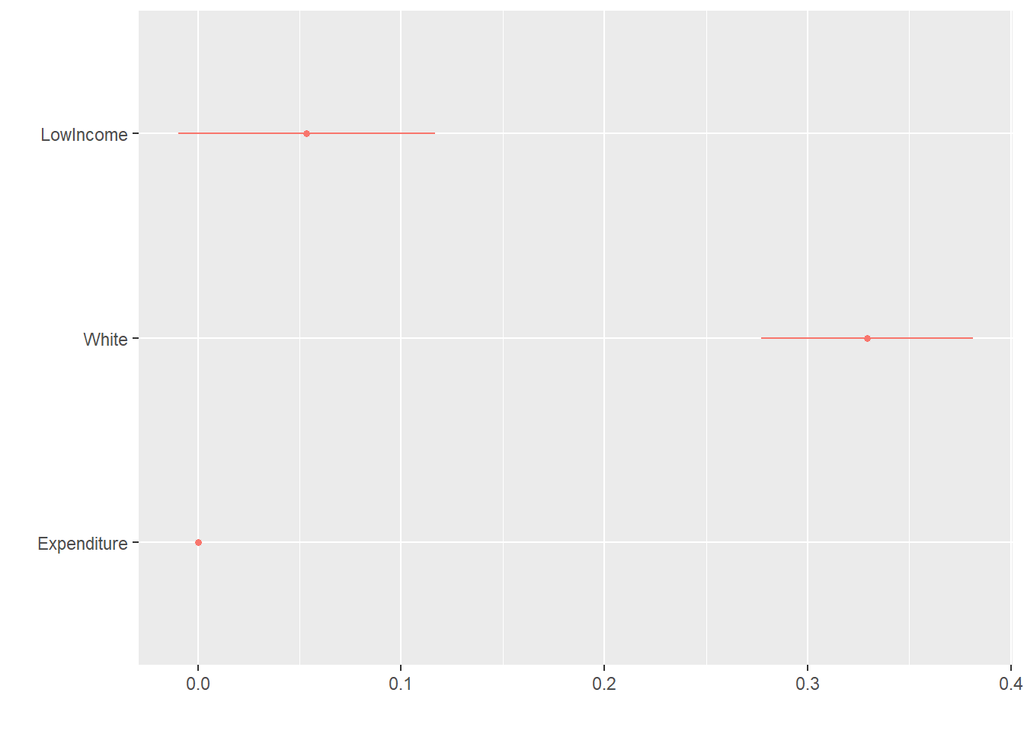

```r
dwplot(gauss3,by_2sd = F)
```

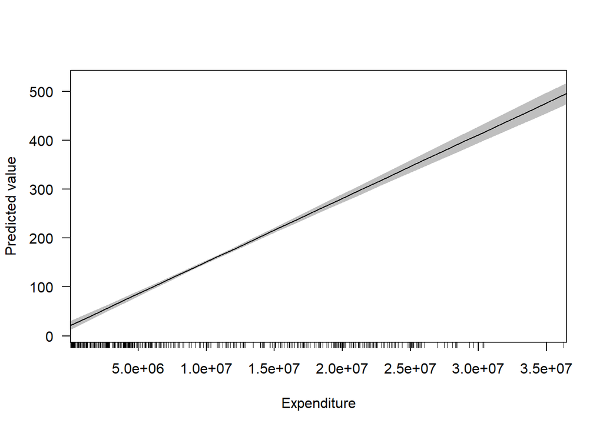

```r
cplot(gauss3, 'Expenditure')
```

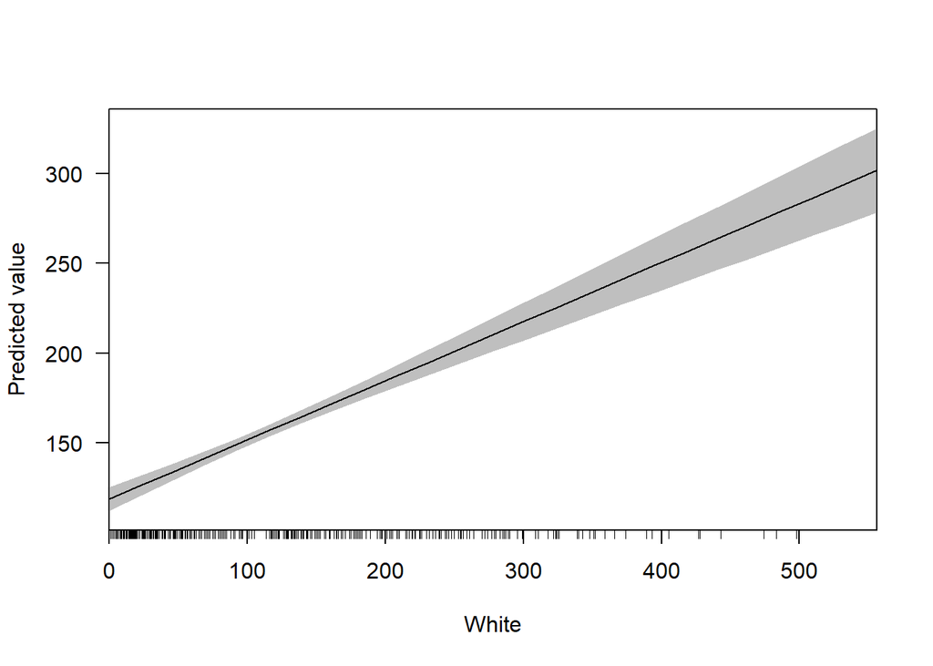

```r
cplot(gauss3, 'White')
```

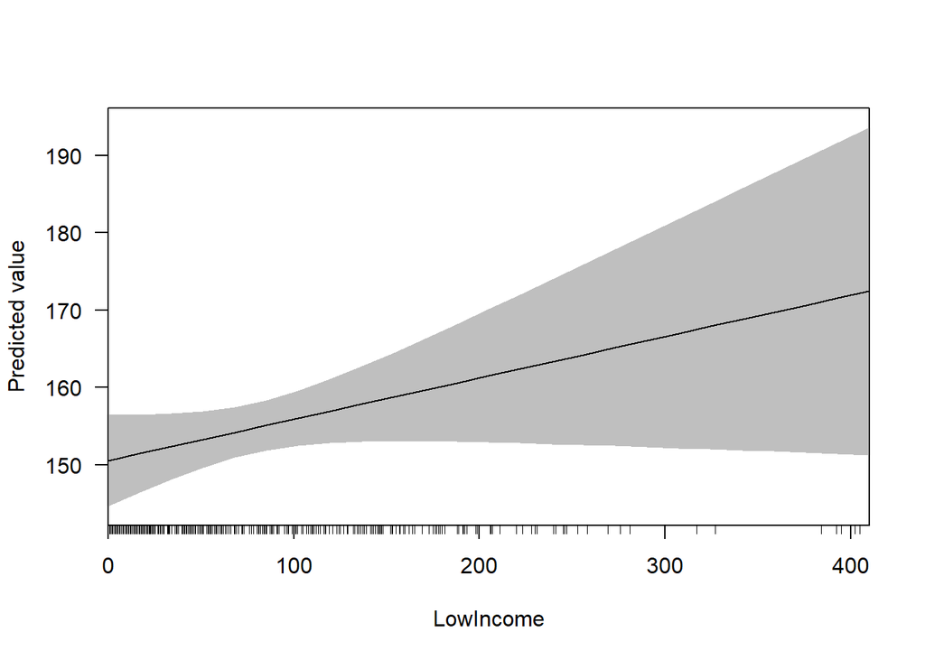

```r
cplot(gauss3, 'LowIncome')
```

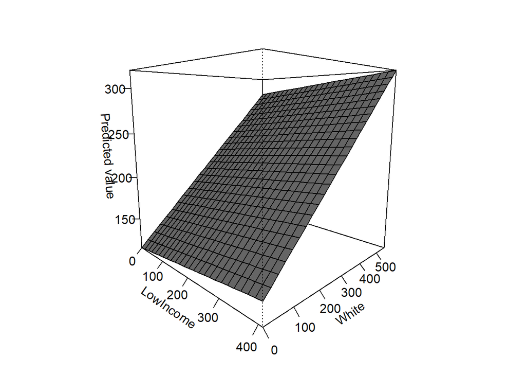

```r
persp(gauss3)
```

#### Confirmation of Computed Predictors

2. Now that I’ve plotted those, I will use the code provided by Professor M. to confirm the marginal effects of each of my predictors.
   - Note: This is an extra step provided for a LOG regression, but it’s nice to have confirmation nonetheless. Note that the marginal effects match the regression values given by Model 3 in prior steps. *

```r
(marginsINFO = margins(gauss3))
```

```
## Average marginal effects
```

```
## glm(formula = hypo3, family = "gaussian", data = fromPy3)
```

```
##  LowIncome  White Expenditure
##    0.05349 0.3293     1.3e-05
```

```r
(marginsSUMM=summary(marginsINFO))
```

```
##       factor    AME     SE       z      p   lower  upper
##  Expenditure 0.0000 0.0000 30.7982 0.0000  0.0000 0.0000
##    LowIncome 0.0535 0.0323  1.6581 0.0973 -0.0097 0.1167
##        White 0.3293 0.0265 12.4041 0.0000  0.2773 0.3813
```

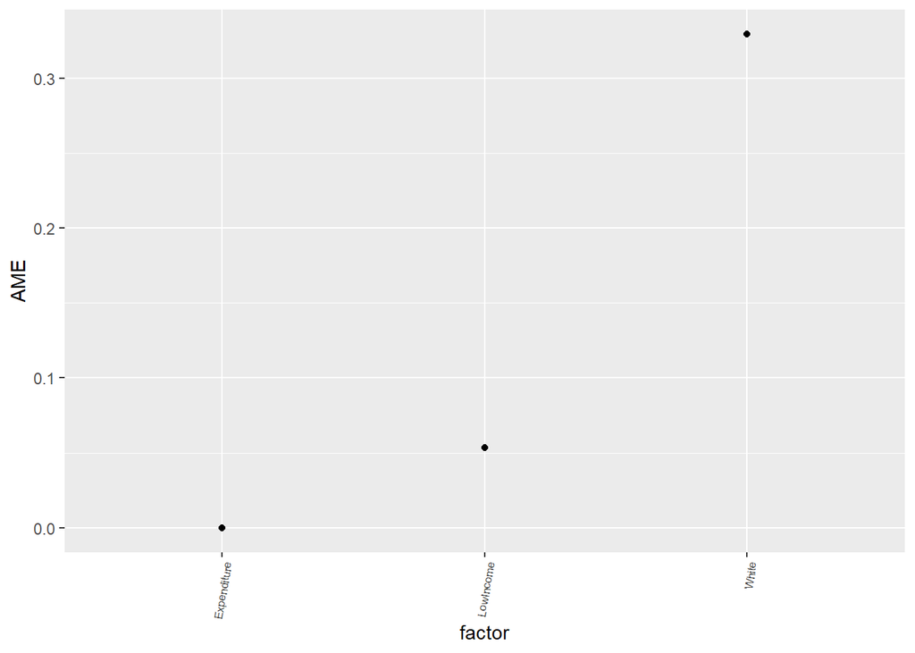

```r
base= ggplot(marginsSUMM,
             aes(x=factor, y=AME))
base= base + geom_point()

plotMargins = base+ theme(axis.text.x = element_text(angle = 80,size = 6,hjust = 1))
plotMargins
```

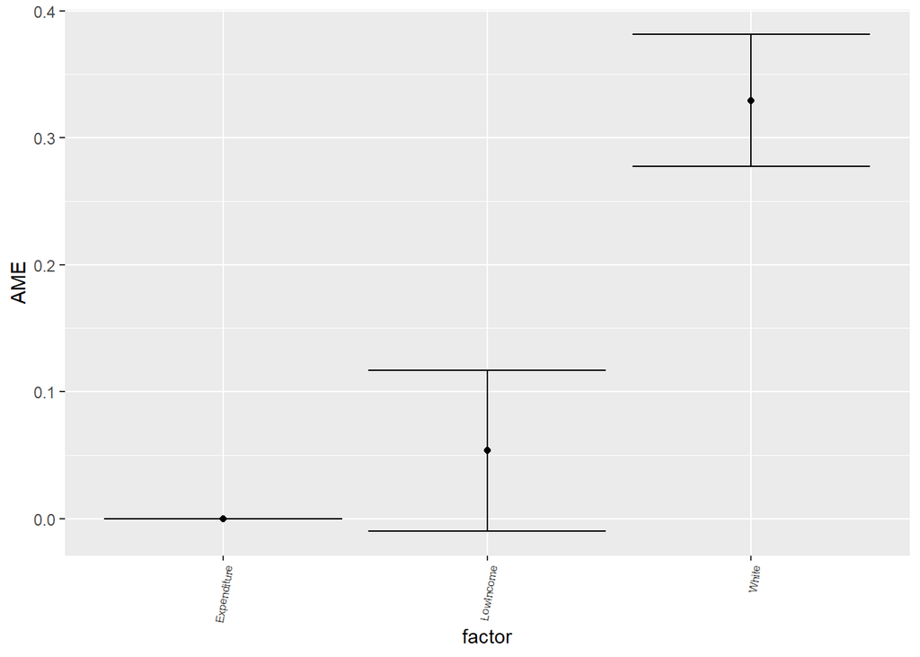

```r
plotMargins + geom_errorbar(aes(ymin=lower,
                                ymax=upper))
```

### THANKS FOR READING!

##### -Group 1 PUBPOL 542 WINTER 2021

##### (Micaela, Nick, Madelyn, and Wenzhen)